# STAT 331 Group Project

- Show All Code
- Hide All Code
- View Source

Author

Katrina, Matina, Lindsey, Kaviya

## Our Hypothesis

Higher CO2 emissions per capita are associated with lower life expectancy.

# 1 Data

### 1.1 Data

The data consists of two datasets that come from [Gapminder](https://www.gapminder.org/data/): Life Expectancy (`life_expectancy_at_birth.csv`) and Consumption-Based CO2 Emissions Per Capita (`co2_pcap_cons.csv`).

In the dataset for Life Expectancy (`life_expectancy_at_birth.csv`), the data collected includes the number of years a newborn infant would live if the current mortality rates at different ages were to stay the same throughout its life across different countries. The dataset originally had 195 rows and 302 columns. After filtering and cleaning, the data consists of 186 rows and 24 columns with mainly double data types. Each row represents a country, with each column representing the life expectancy for a particular country across years from 2000 to 2022. More information about this dataset and its documentation can be found here: [Life Expectancy](https://www.gapminder.org/data/documentation/gd004/).

In the dataset for Consumption-Based CO<sub>2</sub> Emissions Per Capita (`co2_pcap_cons.csv`), the data collected includes the average amount of carbon dioxide emissions per person, taking into account consumption patterns, across different countries. The dataset originally had 194 rows and 224 columns. After filtering and cleaning, the data consists of 194 rows and 24 columns with mainly double data types. Each row provides information about the CO<sub>2</sub> emissions per capita for a particular country across years from 2000 to 2022. More information about this dataset and its documentation can be found here: [CO2 Emissions Consumption Historic Dataset](https://docs.google.com/spreadsheets/d/1t_GOXGrXQgSasIB7dWfRrq9dkqjrqwy3xHvywH7ah1A/edit#gid=501532268).

```r
# Accessing libraries
library(tidyverse)
library(janitor)
library(moderndive)
library(patchwork)
```

```r
# Load in the life expectancy csv
life_exp <-read_csv(here::here("Datasets/life_expectancy_at_birth.csv"))

#load in the carbon emissions data
carbon <-read_csv(here::here("Datasets/co2_pcap_cons.csv"))
```

### 1.2 Data Cleaning

The “Data Cleaning” and “Pivoting Longer” steps are put into one pipeline. Missing values were handled using the `na.omit()` function in order to remove missing values from the two respective data frames. The column names were also changed from character type to numeric type for ease of plotting graphs in future steps.

### 1.3 Pivoting Longer

For the “Pivoting Longer” steps, the years were consolidated into one column `year` and respective values are put into their variables of `carbon_emissions_tonnes` and `life_expectancy_years`.

```r
#cleaning carbon
clean_carbon <- carbon %>%
  na.omit() %>%
  mutate(across(.cols = `2000`:`2022`,
                .fns = ~as.numeric(.x))) %>%
  select(country, `2000`:`2022`) |>
  pivot_longer(cols = !country,
               names_to = "year",
               values_to = "carbon_emissions_tonnes")

clean_life_exp <- life_exp %>%
  na.omit() %>%
  mutate(across(.cols = `2000`:`2022`,
                .fns = ~as.numeric(.x))) %>%
  select(country, `2000`:`2022`) |>
  pivot_longer(cols = !country,
               names_to = "year",
               values_to = "life_expectancy_years")
```

### 1.4 Data Cleaning

Data before pivoting was cleaned in the initial step “1.2 Data Cleaning” so it was not necessary to perform the additional step “Step 1.4: Data Cleaning”.

### 1.5 Joining Datasets

After joining the cleaned datasets to create the final dataset, the years included are from 2000 to 2022 and there are 194 countries. The explanatory variable is `carbon_emissions_tonnes` and the response variable is `life_expectancy_years`.

```r
#joining the two cleaned data sets
joined_data <- left_join(clean_carbon, clean_life_exp, by = c("country", "year"))
```

# 2 Linear Regression

### 2.1 Data Visualization

#### Data Visualization 1

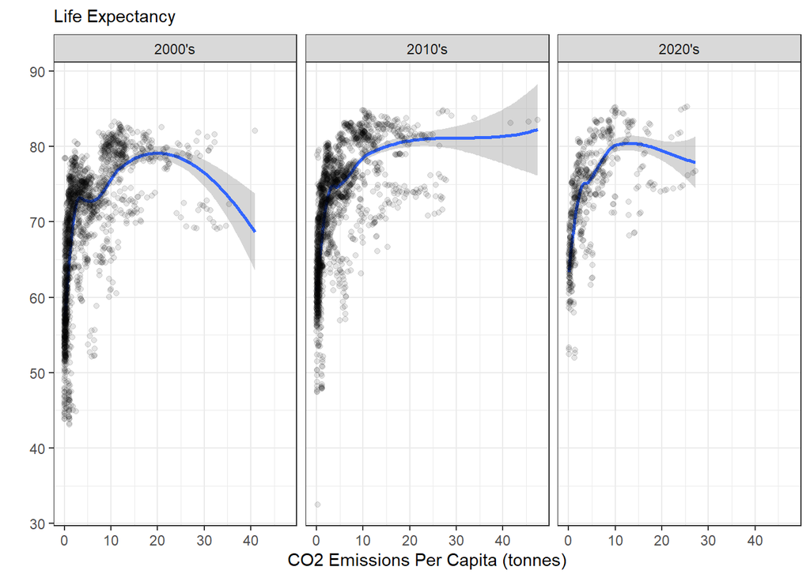

```r
joined_data %>%
  mutate(year=as_factor(year),
          year=fct_collapse(.f=year,
                           "2000's"= 2000:2009,
                            "2010's"= 2010:2019,
                            "2020's"=2020:2022)) %>%
  ggplot(mapping = aes (x = carbon_emissions_tonnes,
                        y = life_expectancy_years)) +
  facet_grid(~ year) +
  geom_smooth(method = "loess")+
  geom_jitter(alpha = 0.1) +
  scale_color_brewer(palette = "Dark2") +
  labs(x = "CO2 Emissions Per Capita (tonnes)",
       subtitle = "Life Expectancy",
       y = "") +
  theme_bw()
```

#### Data Visualization 2

Below we have created another visualization to show the relationship between the consumption-based CO<sub>2</sub> emissions per capita and the life expectancy averaged per country over the years 2000 to 2022. The graph indicates that there is likely not a linear relationship between the two variables. As the average carbon emissions increase between 0 and 5 tons, there is a sharp increase in average life expectancy. However life expectancy begins to plateau to around 75-80 years at 10 to 15 tons of carbon emissions. The overall trend is that as carbon emissions increase, life expectancy also increases, though at different rates.

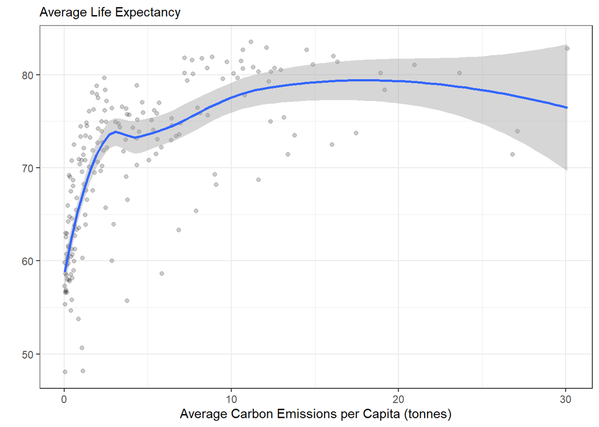

```r
joined_data %>%
  group_by(country) %>%
  summarise(avg_crbn = mean(carbon_emissions_tonnes, na.rm=T),
         avg_life = mean(life_expectancy_years, na.rm=T)) %>%
  ggplot(mapping = aes(x = avg_crbn,
                       y = avg_life)) +
  geom_jitter(alpha = 0.2) +
  geom_smooth(method = "loess") +
  scale_color_brewer(palette = "Dark2") +
  labs(x = "Average Carbon Emissions per Capita (tonnes)",
       subtitle = "Average Life Expectancy",
       y = "") +
  theme_bw()
```

### 2.2 Linear Regression

We used linear regression to model the relationship between the response variable of `life_expectancy_years` and the explanatory variable of `carbon_emissions_tonnes`.

```r
library(broom)

#create a new dataset similar to the top 10 country one but Instead let's use the data from all the countries to see the correlation between a countries average carbon emissions with the average life expectancy
lm_data <- joined_data |>
  group_by(country) |>
  summarise(avg_crbn = mean(carbon_emissions_tonnes, na.rm=T),
         avg_life = mean(life_expectancy_years, na.rm=T))

lm_crbn_life <- lm(avg_life~avg_crbn, data = lm_data)
lm_crbn_life
```

```
Call:
lm(formula = avg_life ~ avg_crbn, data = lm_data)

Coefficients:
(Intercept)     avg_crbn
    66.5120       0.8326
```

The model represents the relationship using the equation:
$$AverageLifeExpectancy = \beta_0 + \beta_1 * AverageCarbonEmissions + ε$$
. The coefficient *B<sub>0</sub>* represents the average life expectancy when the average carbon emissions equal zero. The coefficient *B<sub>1</sub>* represents the average carbon emissions and how much the average life expectancy changes for each additional unit of carbon emissions. *ε* represents the error term, which is the difference between the actual observed life expectancy and predicted life expectancy.

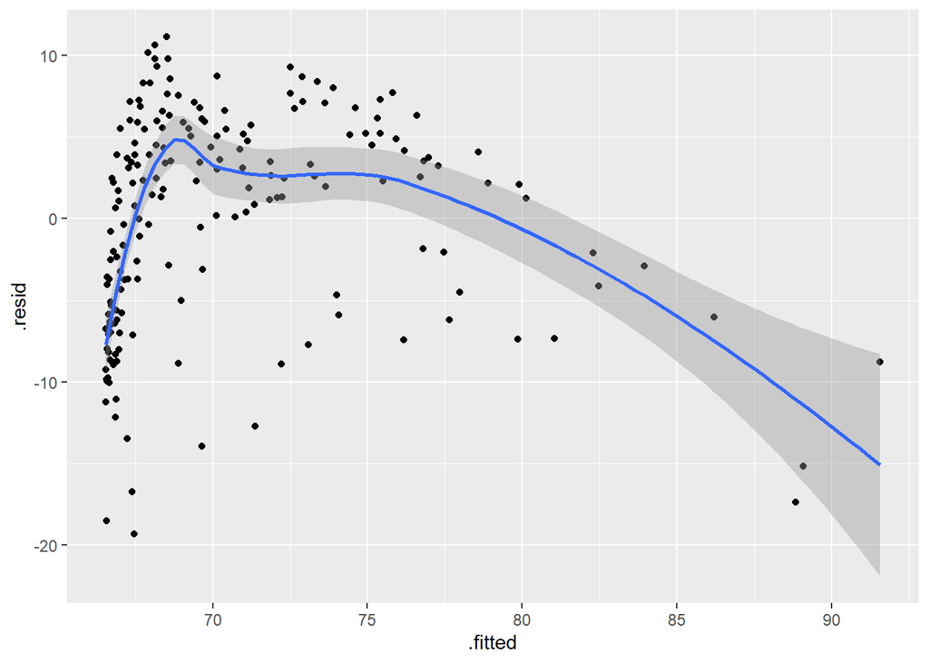

```r
lm_crbn_life %>%
  ggplot(aes( x = .fitted , y=.resid))+
  geom_jitter()+
  geom_smooth(method = "loess")
```

### 2.3 Model Fit

Using the values from the regression model, the table is constructed below with the following variables: `var_y`, `var_y_hat`, `var_residual`, and `r_squared`. `var_y` represents the variance in the response values. `var_y_hat` represents the variance in the fitted values. `var_residual` represents the variance in the residuals. `r_squared`represents the proportion of the spread/variation of the outcome variable `avg_life` explained by the model.

To evaluate the quality of the regression model, we compute the R<sup>2</sup> value. The R<sup>2</sup> value for the regression model is approximately 0.342. This means that around 34.2% of the variability in the response values is accounted for by the model.

In terms of the “quality” of the model, this suggests a moderate level of fit. While the model does explain some of the variance in the response variable, a significant portion (approximately 65.8%) of the variance is not explained by the model. This could mean that there are other variables not included in the model that are influencing the response, or that the model is not capturing the relationship between the variables effectively.

```r
model_fit <- get_regression_points(lm_crbn_life) %>%
  summarize(var_y = round(var(avg_life),1),
                      var_y_hat = round(var(avg_life_hat),1),
                      var_residual = round(var(residual),1),
                      r_squared = round(1-(var_residual/var_y),3))

knitr::kable((model_fit),format = "html")
```

| var_y | var_y_hat | var_residual | r_squared |
| --- | --- | --- | --- |
| 66.6 | 22.8 | 43.8 | 0.342 |

## 3 Simulation

### 3.1 Visualizing Simulations from the Model

With our simple linear regression, predictions were generated using the `predict()` function. Random errors were added to the predictions using the residual standard error estimated from the linear regression model, which were acquired with the `sigma()` function.

```r
predictions <- predict(lm_crbn_life)
sig_data <- sigma(lm_crbn_life)

noise <- function(x, mean = 0, sd){
  x + rnorm(length(x),
            mean,
            sd)
}


simulations <- tibble(predicted_lf = noise(predictions,
                                           sd = sig_data)
                   )

sim_data <- lm_data |>
  filter(!is.na(avg_crbn),
         !is.na(avg_life)
         ) |>
  select(avg_crbn, avg_life) |>
  bind_cols(simulations)

head(sim_data)
```

```
# A tibble: 6 × 3
  avg_crbn avg_life predicted_lf
     <dbl>    <dbl>        <dbl>
1    0.194     60.1         59.5
2    2.02      77.5         70.6
3    3.33      74.3         65.0
4    1.10      60.3         61.6
5    5.54      75.9         79.8
6    3.89      75.7         76.3
```

Simulated observations were then compared to the observed data by generating the same plot of the relationships modeled by the linear regression, for the simulated data made during “2.1 Data Visualizations”.

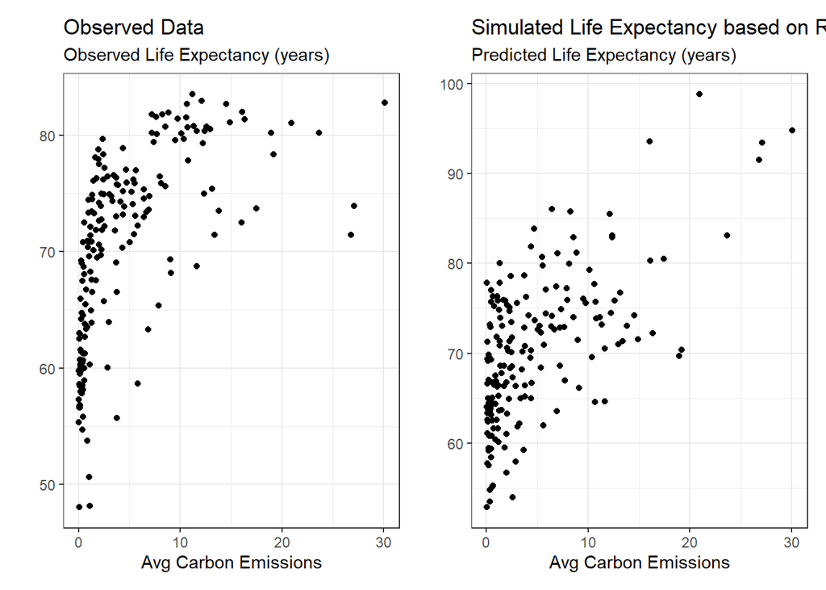

```r
predicted_plot <- sim_data %>%
  ggplot(mapping = aes(x = avg_crbn,
                       y = predicted_lf)) +
  geom_point() +
  labs(x = "Avg Carbon Emissions",
       y = "",
       subtitle = "Predicted Life Expectancy (years)",
       title = "Simulated Life Expectancy based on Regression Model ") +
  theme_bw()

# the dataset here needs to be changed
observed_plot <- lm_data %>%
  ggplot(mapping = aes(x=avg_crbn,
                       y = avg_life)) +
  geom_point() +
  labs(x = "Avg Carbon Emissions",
       y = "",
       subtitle = "Observed Life Expectancy (years)",
       title = "Observed Data") +
  theme_bw()

observed_plot + predicted_plot
```

### 3.2 Generating Multiple Predictive Checks

```r
# Number of simulations
nsims <- 1000
sims <- map_dfc(.x = 1:nsims,
                .f = ~ tibble(sim = noise(predictions,
                                          sd = sig_data)
                              )
                )

# Renaming column names
colnames(sims) <- colnames(sims) |>
  str_replace(pattern = "\\.\\.\\.",
                  replace = "_")

# Add observed response to simulated data set
sims <- lm_data |>
  filter(!is.na(avg_crbn),
         !is.na(avg_life)) |>
  select(avg_life) |>
  bind_cols(sims)

# Inspecting R2 values
sim_r_sq <- sims |>
  map(~ lm(avg_life ~ .x, data = sims)) |>
  map(glance) |>
  map_dbl(~ .x$r.squared)

# Removing unwanted entry of avg_life
sim_r_sq <- sim_r_sq[names(sim_r_sq) != "avg_life"]
```

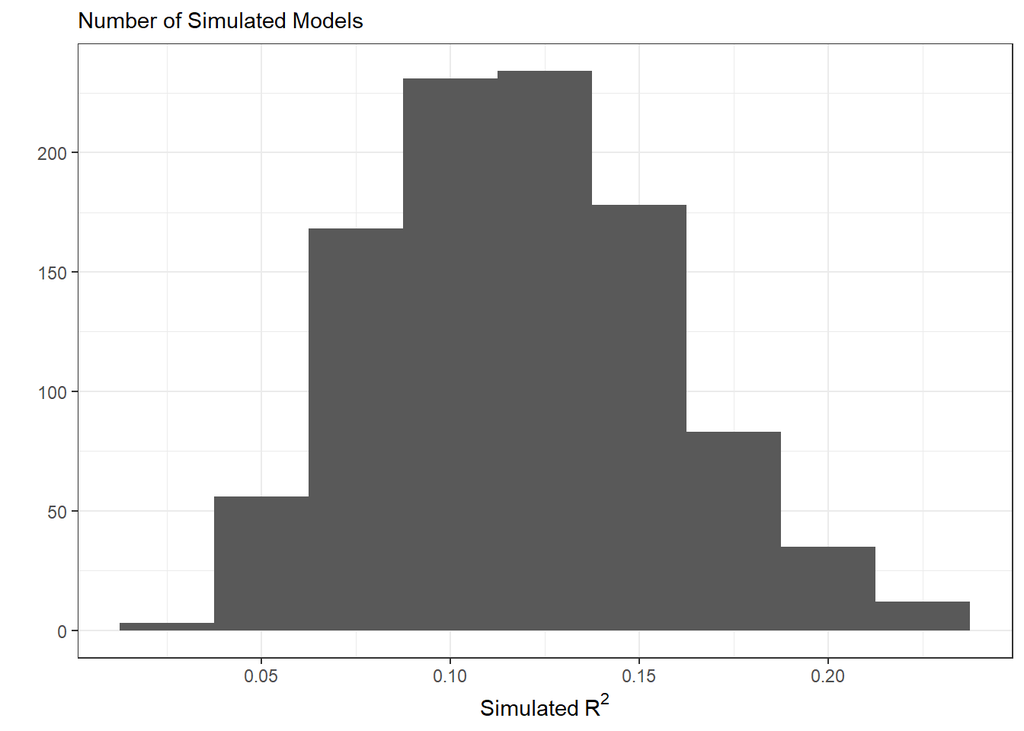

```r
# Plotting the simulated R2 values vs observed R2 values
tibble(sims = sim_r_sq) |>
  ggplot(aes(x = sims)) +
  geom_histogram(binwidth = 0.025) +
  labs(x = expression("Simulated"~ R^2),
       y = "",
       subtitle = "Number of Simulated Models") +
  theme_bw()
```

The histogram depicting the relationship between average lifespan and carbon emissions shows low R<sup>2</sup> values, indicating that carbon emissions alone provide limited explanatory power for predicting lifespan. This suggests that the model currently does not generate data that closely approximates what is observed, likely due to the complex nature of the underlying relationship. Lifespan is influenced by many factors beyond emissions, including socioeconomic status, public health infrastructure, and individual behaviors. Thus, the model may require additional variables to capture this complexity. The consistent but low R<sup>2</sup> values across simulations also suggest a need for exploring non-linear relationships or interactions through more sophisticated statistical models.